# Does depth divide? Variable genetic connectivity patterns among shallow and mesophotic Montastraea cavernosa coral populations across the Gulf of Mexico and Western Caribbean: Analyses and Figures in R

Alexis Sturm – lexie.sturm@gmail.com and Ryan Eckert– ryan.j.eckert@gmail.com

11/30/2022

# About this document

Code to produce these figures was generated with help from [Ryan Eckert](https://ryanjeckert.weebly.com), if you think this walkthrough is helpful check out similar ones for *Stephanocoenia intersepta* analyses [here](https://github.com/RyanEckert/Stephanocoenia_FKNMS_PopGen).

If you have any issues or questions about the code please feel free to send an email to lexie.sturm@gmail.com or follow up with her at her website (https://alexisbsturm.weebly.com){target=“_blank”}.

# Basic setup of R environment

## Loading required packages

For the following analyses we will require the use of multiple different R packages, we can use the package *pacman* to quickly load them.

```r
if (!require("pacman")) install.packages("pacman")
```

```r
pacman::p_load("adegenet", "dendextend", "gdata", "ggdendro", "hierfstat", "Imap", "kableExtra", "paletteer", "patchwork", "officer", "poppr", "RColorBrewer", "reshape2", "StAMPP", "tidyverse", "vcfR", "vegan", "WGCNA", "ggnewscale", "rnaturalearth", "sf", "ggspatial", "cowplot", "dplyr", "grDevices", "sdmpredictors", "leaflet", "adespatial",
"codep", "adegraphics", "ape", "car", "psych", "raster", "rgdal", "Hmisc","pairwiseAdonis", "pcadapt", "ggmap", "TeachingDemos", "LaplacesDemon")

pacman::p_load_gh("eliocamp/ggnewscale", "ropensci/rnaturalearthhires","moldach/vapoRwave", "coolbutuseless/emphatic")
```

Figures, Tables, and Analyses *** #Sample Sites

```r
#Table 1:Sample locations and number of samples
meta=read.csv("../data/regionalInds2PopsNoClones.csv")
sampleTableRegion= meta %>%
  group_by(region, depthZone) %>%
  summarise(n = n(), depthMin= min(depthM), depthMax=max(depthM), meanDepth=mean(depthM))
sampleTableRegion=data.frame(sampleTableRegion)

sampleTableSite= meta %>%
  group_by(region, site, depthZone, lat, lon) %>%
  summarise(n = n())
sampleTableSite=data.frame(sampleTableSite)
```

#Algal symbiont analyses

The following chunk uses any 2bRAD sequences that align exclusively to the algal symbiont genomes. These were aligned to genomes for *Symbiodinium*, *Breviolum*, *Cladocopium*, and *Durusdinium* and we can use these sequence alignments as a proxy for algal symbiont community structure at the genera level.

##Downloading algal symbiont 2bRAD reads

```r
  meta=read.csv("../data/regionalInds2PopsNoClones.csv") # Reads in population data for each sample
  #Reading in algal symbiont aligned 2bRAD sequences
  zoox = read.delim("../data/zooxGenomeAlignmentRate", header = FALSE, check.names = FALSE)
  head(zoox)
```

```
##                                   V1 V2
## 1 blz_001.trim.zoox.zooxOnly.bt2.bam NA
## 2                               chr1  0
## 3                               chr2  0
## 4                               chr3  0
## 5                               chr4  2
## 6                               chr5  0
```

```r
  zoox$V2[is.na(zoox$V2)] <- as.character(zoox$V1[is.na(zoox$V2)])
  zoox$V1 = gsub(pattern = "*.trim.zoox.zooxOnly.bt2.bam", "chr", zoox$V1)
  zoox$V2 = gsub(".trim.*", "", zoox$V2)

  zoox = zoox %>% filter(zoox$V1 != "*")

  zooxLst = split(zoox$V2, as.integer(gl(length(zoox$V2), 20, length(zoox$V2))))

  zooxMaps = NULL
  for(i in zooxLst){
    zooxMaps = rbind(zooxMaps, data.frame(t(i)))
  }
  colnames(zooxMaps) = c("sample",zoox$V1[c(2:20)])

  for(i in c(2:20)){
    zooxMaps[,i] = as.numeric(levels(zooxMaps[,i]))[zooxMaps[,i]]
  }

  str(zooxMaps)
```

```
## 'data.frame':    752 obs. of  20 variables:
##  $ sample: Factor w/ 752 levels "blz_001","blz_003",..: 1 2 3 4 5 6 7 8 9 10 ...
##  $ chr1  : num  0 5 16 29 14 31 12 14 5 29 ...
##  $ chr2  : num  0 5 26 46 4 16 6 4 2 16 ...
##  $ chr3  : num  0 2 9 29 18 19 8 18 3 14 ...
##  $ chr4  : num  2 4 16 56 9 36 15 12 2 37 ...
##  $ chr5  : num  0 0 0 3 0 3 0 0 0 3 ...
##  $ chr6  : num  0 0 10 22 2 23 5 8 0 21 ...
##  $ chr7  : num  0 3 9 25 4 20 6 5 1 13 ...
##  $ chr8  : num  4 3 73 96 5 59 12 54 1 101 ...
##  $ chr9  : num  7 6 84 72 2 43 42 127 9 81 ...
##  $ chr10 : num  263 339 6138 16832 1800 ...
##  $ chr11 : num  358 135 8928 23598 76 ...
##  $ chr12 : num  311 139 9010 24381 55 ...
##  $ chr13 : num  321 129 9010 23435 45 ...
##  $ chr14 : num  309 134 8728 22303 127 ...
##  $ chr15 : num  59 46 1478 3115 45 ...
##  $ chr16 : num  5 59 50 167 423 100 118 163 74 58 ...
##  $ chr17 : num  3 14 35 103 74 92 35 68 21 55 ...
##  $ chr18 : num  6 33 16 97 118 47 39 78 23 42 ...
##  $ chr19 : num  1 5 7 12 43 5 12 27 4 12 ...
```

```r
  zooxMaps$Symbiodinium = rowSums(zooxMaps[2:6])
  zooxMaps$Breviolum = rowSums(zooxMaps[7:10])
  zooxMaps$Cladocopium = rowSums(zooxMaps[11:16])
  zooxMaps$Durusdinium = rowSums(zooxMaps[17:20])

  zooxMaps = zooxMaps[,c(1, 21:24)]

  zooxMapsSums=zooxMaps
  zooxMapsSums$totalAlignments=rowSums(zooxMapsSums[2:5])
  mean(zooxMapsSums$Cladocopium)/mean(zooxMapsSums$totalAlignments) #Cladocopium dominant
```

```
## [1] 0.988755
```

```r
  zooxProp = zooxMaps

  zooxProp$sum = apply(zooxProp[, c(2:length(zooxProp[1,]))], 1, function(x) {
    sum(x, na.rm = T)
  })

  zooxProp = cbind(zooxProp[, c(1)], (zooxProp[, c(2:(ncol(zooxProp)-1))]
                                      / zooxProp$sum))
  head(zooxProp)
```

```
##   zooxProp[, c(1)] Symbiodinium   Breviolum Cladocopium Durusdinium
## 1          blz_001  0.001212856 0.006670710   0.9830200 0.009096422
## 2          blz_003  0.015080113 0.011310085   0.8689915 0.104618285
## 3          blz_004  0.001535183 0.004032720   0.9919575 0.002474624
## 4          blz_005  0.001424564 0.001879026   0.9933841 0.003312329
## 5          blz_006  0.015712291 0.004539106   0.7500000 0.229748603
## 6          blz_007  0.001001345 0.001382809   0.9952889 0.002326934
```

```r
  apply(zooxProp[, c(2:(ncol(zooxProp)))], 1, function(x) {
    sum(x, na.rm = T)
  })
```

[output not shown]

```r
  head(meta)
```

```
##    sample site                 pop region depthM depthZone dateCollected      lat
## 1 blz_001   RW Belize Barrier Reef    BLZ   10.7   Shallow       3/23/17 16.77607
## 2 blz_003   RW Belize Barrier Reef    BLZ   10.1   Shallow       3/23/17 16.77607
## 3 blz_004   RW Belize Barrier Reef    BLZ   10.4   Shallow       3/23/17 16.77607
## 4 blz_005   RW Belize Barrier Reef    BLZ   10.7   Shallow       3/23/17 16.77607
## 5 blz_006   SR Belize Barrier Reef    BLZ    8.5   Shallow       3/24/17 16.76895
## 6 blz_007   SR Belize Barrier Reef    BLZ    9.1   Shallow       3/24/17 16.76895
##         lon regionDepth
## 1 -88.07465  BLZShallow
## 2 -88.07465  BLZShallow
## 3 -88.07465  BLZShallow
## 4 -88.07465  BLZShallow
## 5 -88.07388  BLZShallow
## 6 -88.07388  BLZShallow
```

```r
  dfZoox = cbind("sample" = zooxProp[,1], "region" = meta[,4], "depthZone" = meta[,6], "regionDepth" = meta[,10], zooxProp[,c(2:5)])
  #dfZoox$regionDepth=as.factor(dfZoox$regionDepth)
  #dfZoox$regionDepth = factor(dfZoox$regionDepth, levels = levels(dfZoox$regionDepth)[c(6,5,4,3,2,1,8,7)])
  dfZoox = dfZoox[order(dfZoox$regionDepth),]
  dfZoox$Order = c(1:nrow(dfZoox))

  zDat = melt(dfZoox, id.vars = c("sample", "region", "depthZone", "regionDepth", "Order"), variable.name = "Symbiont", value.name = "Fraction")
```

##Plotting algal symbiont community structure at the genus level

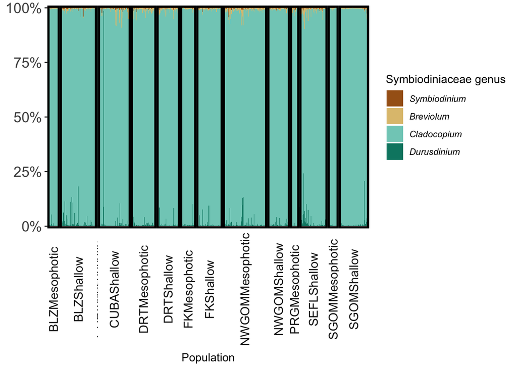

```r
colPalZoox = brewer.pal(4, "BrBG")
names(colPalZoox) = levels(zDat$Symbiont)

  zooxPlotA = ggplot(data = zDat, aes(x = Order, y = Fraction, fill = Symbiont, order = Order)) +
    geom_bar(stat="identity", position="fill", width=1) +
    #geom_bar(stat = "identity", position = "stack", colour = "grey25", width = 1) +
    xlab("Population") +
    scale_x_discrete(expand = c(0, 0)) +
    scale_y_continuous(expand = c(0, 0), labels = function(x) paste0(x*100, "%")) +
    scale_fill_manual(values = colPalZoox, name = "Symbiodiniaceae genus") +
    coord_cartesian(ylim = c(-.01,1.01)) +
    facet_grid(.~fct_inorder(regionDepth), drop=TRUE, scales = "free", switch = "x", space = "free") +
    theme_bw()

  zooxPlot = zooxPlotA + theme(plot.title = element_text(hjust = 0.5),
                               panel.grid=element_blank(),
                               panel.background=element_rect(fill=NA, colour="grey25"),
                               panel.spacing.x=grid:::unit(0, "lines"),
                               panel.border = element_rect(color="black", size=2, linetype="solid"),
                               axis.text.y=element_text(size=14),
                               axis.text.x = element_blank(),
                               axis.title.y = element_blank(),
                               axis.ticks.x=element_blank(),
                               strip.background=element_blank(),
                               strip.text=element_text(size=12, angle=90),
                               legend.key=element_blank(),
                               legend.position = "right",
                               #legend.title = element_blank(),
                               legend.text = element_text(face = "italic"))

  zooxPlot
```

```r
  ggsave("../figures/zooxPlot.tiff", plot = zooxPlot, width = 34.35, height = 12.5, units = "cm", dpi = 300)
```

As we can see *Cladocopium* communities are dominant across almost all samples, but is there significant variation in the background genera of algal symbionts?

##Figure 1:Plotting algal symbiont NMDS

```r
#make community matrix - extract columns with abundance information
com = (zooxMaps[,2:ncol(zooxMaps)]) #extracting community matrix
m_com = as.matrix(com) #making it a matric
set.seed(123)
nmds = metaMDS(m_com, distance = "bray", try = 100) #Running the NMDS
```

```
## Square root transformation
## Wisconsin double standardization
## *** No convergence -- monoMDS stopping criteria:
##     18: no. of iterations >= maxit
##     66: stress ratio > sratmax
##     16: scale factor of the gradient < sfgrmin
```

```r
nmds
```

```
##
## Call:
## metaMDS(comm = m_com, distance = "bray", try = 100)
##
## global Multidimensional Scaling using monoMDS
##
## Data:     wisconsin(sqrt(m_com))
## Distance: bray
##
## Dimensions: 2
## Stress:     0.06061689
## Stress type 1, weak ties
## No convergent solutions - best solution after 100 tries
## Scaling: centring, PC rotation, halfchange scaling
## Species: expanded scores based on 'wisconsin(sqrt(m_com))'
```

```r
data.scores = as.data.frame(scores(nmds)) #extracting these values
data.scores = cbind("sample" = zooxMaps[,1], "region" = meta[,4], "depthZone" = meta[,6], "regionDepth" = meta[,10], data.scores) #binding metadata together
set.seed(694) #setting seed allows repetition of randomized processes
head(data.scores)
```

```
##    sample region depthZone regionDepth        NMDS1       NMDS2
## 1 blz_001    BLZ   Shallow  BLZShallow -0.141654360  0.04505033
## 2 blz_003    BLZ   Shallow  BLZShallow  0.107405729 -0.31784927
## 3 blz_004    BLZ   Shallow  BLZShallow -0.003641461  0.03174227
## 4 blz_005    BLZ   Shallow  BLZShallow  0.165600898  0.03718826
## 5 blz_006    BLZ   Shallow  BLZShallow  0.288032298 -0.50191034
## 6 blz_007    BLZ   Shallow  BLZShallow  0.196788058  0.08763691
```

```r
zooxGenFit <- envfit(nmds, m_com, permutations = 999) #Adding indicator species vectors
head(zooxGenFit)
```

```
## $vectors
##                 NMDS1    NMDS2     r2 Pr(>r)
## Symbiodinium  0.81084 -0.58527 0.1676  0.001 ***
## Breviolum     0.44937  0.89335 0.1388  0.001 ***
## Cladocopium   0.58578  0.81047 0.2279  0.001 ***
## Durusdinium   0.03543 -0.99937 0.1916  0.001 ***
## ---
## Signif. codes:  0 '***' 0.001 '**' 0.01 '*' 0.05 '.' 0.1 ' ' 1
## Permutation: free
## Number of permutations: 999
##
## $factors
## NULL
##
## $na.action
## function (object, ...)
## UseMethod("na.action")
## <bytecode: 0x7fd1f9ad3870>
## <environment: namespace:stats>
```

```r
zooxSppScores <- as.data.frame(scores(zooxGenFit, display = "vectors")) #extracts relevant scores from envifit
A <- as.list(zooxGenFit$vectors)
pvals<-as.data.frame(A$pvals)
arrows<-as.data.frame(A$arrows*sqrt(A$r))
C<-cbind(arrows, pvals)
Cred<-subset(C,pvals<0.01)
Cred <- cbind(Cred, Species = rownames(Cred))

data.scores = merge(data.scores, aggregate(cbind(mean.x = NMDS1, mean.y = NMDS2)~regionDepth, data.scores, mean), by="regionDepth")

  #%>% merge(., aggregate(cbind(mean.x.K = dbRDA1, mean.y.K = dbRDA2)~K, regionalDbrdaData1, mean), by="K")

data.scores$depthZone = factor(data.scores$depthZone)
data.scores$depthZone = factor(data.scores$depthZone, levels(data.scores$depthZone)[c(2,1)])
data.scores$region = factor(data.scores$region)
data.scores$region = factor(data.scores$region, levels = levels(data.scores$region)[c(7, 4, 3, 6, 2, 5, 8, 1)])

head(data.scores)
```

```
##     regionDepth  sample region  depthZone      NMDS1       NMDS2     mean.x    mean.y
## 1 BLZMesophotic blz_047    BLZ Mesophotic 0.12182640  0.12612442 0.07457383 0.0330474
## 2 BLZMesophotic blz_051    BLZ Mesophotic 0.14895688  0.02967759 0.07457383 0.0330474
## 3 BLZMesophotic blz_052    BLZ Mesophotic 0.05000146  0.14623097 0.07457383 0.0330474
## 4 BLZMesophotic blz_053    BLZ Mesophotic 0.04853362 -0.05203314 0.07457383 0.0330474
## 5 BLZMesophotic blz_054    BLZ Mesophotic 0.22670471  0.16249462 0.07457383 0.0330474
## 6 BLZMesophotic blz_055    BLZ Mesophotic 0.13478592 -0.16635365 0.07457383 0.0330474
```

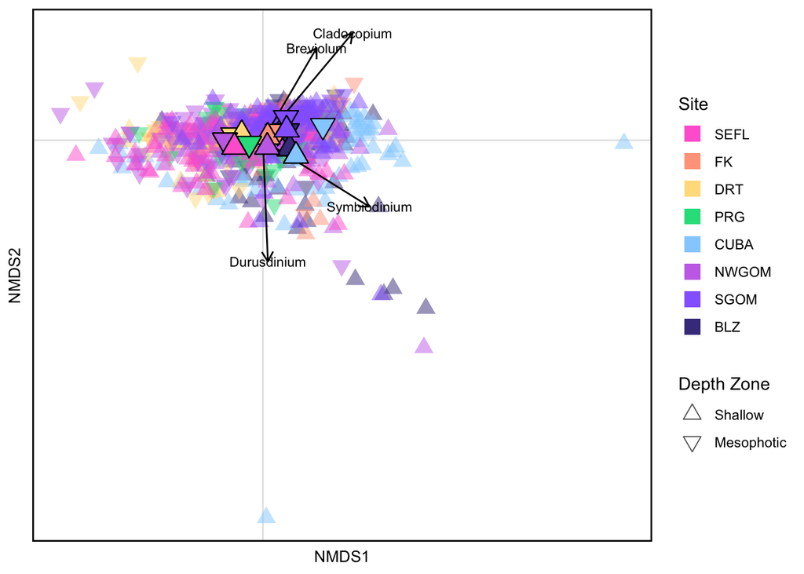

```r
colPal = c(paletteer_d("vapeplot::vaporwave")[c(7,10,11,14,1,5,3)], "slateblue4")
zooxNMDSA = ggplot() +
  geom_hline(yintercept = 0, color = "gray90", size = 0.5) +
  geom_vline(xintercept = 0, color = "gray90", size = 0.5) +
  geom_point(data = data.scores, aes(x = NMDS1, y = NMDS2, fill = region, shape = depthZone), size = 2, stroke = NA,
 alpha = 0.5, show.legend = FALSE) +
  geom_segment(data = Cred,aes(x = 0, xend = NMDS1, y = 0, yend = NMDS2), arrow = arrow(length = unit(0.25, "cm")), colour = "black") +
  scale_shape_manual(values = c(24,25), name = "Depth Zone") +
  # geom_segment(data = regionalDbrdaData, aes(x = mean.x, y = mean.y, xend = dbRDA1, yend = dbRDA2, color = pop), size = 0.5, alpha = 0.5) +
  #geom_segment(data = envLoad, aes(x = 0, y = 0, xend = dbRDA1, yend = dbRDA2),
               #color = "black", arrow = arrow(length = unit(0.25, "cm"), type = "open"), size = 0.65) +
  #geom_text(data = envLoad, aes(x = dbRDA1, y = dbRDA2+0.1, label = var), color = "black", size = 3) +
  #geom_point(data = subset(data.scores, region !=("NWGOM")), aes(x = mean.x, y = mean.y, fill = region, shape = depthZone), size = 2, stroke = NA, alpha = 0.5) +
  geom_point(data = data.scores, aes(x = mean.x, y = mean.y, fill = region, shape = depthZone), size = 5, color = "black") + #population centroids indicated by triangles
  geom_text(data = Cred, aes(x = NMDS1, y = NMDS2, label = Species), size = 3)+
  scale_fill_manual(values = colPal, name = "Site") +
  scale_color_manual(values = colPal, name = "Site") +
  guides(shape = guide_legend(override.aes = list(size = 3.5, stroke = 0.5, alpha = 0.7), order = 2), fill = guide_legend(override.aes = list(shape = 22, size = 5, color = NA, alpha = NA), order = 1))+
  theme_bw()

zooxNMDS = zooxNMDSA +
  theme(axis.title.x = element_text(color = "black", size = 10),
        axis.text.x = element_blank(),
        axis.ticks.x = element_blank(),
        axis.line.x = element_blank(),
        axis.title.y = element_text(color = "black", size = 10),
        axis.text.y = element_blank(),
        axis.ticks.y = element_blank(),
        axis.line.y = element_blank(),
        legend.position = "right",
        panel.border = element_rect(color = "black", size = 1),
        panel.background = element_rect(fill = "white"),
        panel.grid.major = element_blank(),
        panel.grid.minor = element_blank())


zooxNMDS
```

```r
ggsave("../figures/fig1.tiff", plot = zooxNMDS, height = 5, width = 7, units = "in", dpi = 300)
```

Again we can visualize tight overlap in algal symbiont communities amond different samples, but there appears to be some slight variation in algal symbiont communities across site, potentially driven by variation in background algal symbiont communities (non-*Cladocopium*)

Let’s test it: ##Running PERMANOVAs on algal symbiont 2bRAD sequences

```r
zooxGen = cbind("sample" = zooxMaps[,1], "region" = meta[,4], "depthZone" = meta[,6], "regionDepth" = meta[,10], sqrt(zooxMaps[,c(2:5)])) #Square-root transforming the data

set.seed(694) #setting seed allows repetition of randomized processes
zooxGenS = betadisper(vegdist(zooxGen[, c(5:ncol(zooxGen))]), zooxGen$region)
anova(zooxGenS)
```

```
## Analysis of Variance Table
##
## Response: Distances
##            Df  Sum Sq  Mean Sq F value   Pr(>F)
## Groups      7  0.6183 0.088334  3.3234 0.001715 **
## Residuals 744 19.7749 0.026579
## ---
## Signif. codes:  0 '***' 0.001 '**' 0.01 '*' 0.05 '.' 0.1 ' ' 1
```

```r
#There was a significant effect of site on beta diversity

set.seed(694)
zooxGenD = betadisper(vegdist(zooxGen[, c(5:ncol(zooxGen))]), zooxGen$depthZone)
anova(zooxGenD)
```

```
## Analysis of Variance Table
##
## Response: Distances
##            Df  Sum Sq  Mean Sq F value Pr(>F)
## Groups      1  0.0238 0.023795  0.8166 0.3665
## Residuals 750 21.8540 0.029139
```

```r
#However, there was no significant effect of depth on beta diversity

#PERMANOVA
set.seed(344)
its2Adonis = adonis(zooxGen[, c(5:ncol(zooxGen))] ~ region * depthZone,
data = zooxGen, permutations = 99, method = "bray")
its2Adonis
```

```
##
## Call:
## adonis(formula = zooxGen[, c(5:ncol(zooxGen))] ~ region * depthZone,      data = zooxGen, permutations = 99, method = "bray")
##
## Permutation: free
## Number of permutations: 99
##
## Terms added sequentially (first to last)
##
##                   Df SumsOfSqs MeanSqs F.Model      R2 Pr(>F)
## region             7    14.974 2.13910 25.2879 0.18965   0.01 **
## depthZone          1     0.134 0.13355  1.5788 0.00169   0.15
## region:depthZone   5     1.418 0.28359  3.3525 0.01796   0.01 **
## Residuals        738    62.427 0.08459         0.79069
## Total            751    78.953                 1.00000
## ---
## Signif. codes:  0 '***' 0.001 '**' 0.01 '*' 0.05 '.' 0.1 ' ' 1
```

```r
#Pairwise PERMANOVA
set.seed(694)
its2PWAdonis = pairwise.adonis(zooxGen[, c(5:ncol(zooxGen))],
factors = zooxGen$region, sim.method = "bray", p.adjust.m = "BH", perm = 99)
its2PWAdonis
```

```
##            pairs Df   SumsOfSqs     F.Model          R2 p.value p.adjusted sig
## 1    BLZ vs CUBA  1  1.57285911  15.2803313 0.073364255    0.01 0.01555556   .
## 2     BLZ vs DRT  1  0.09092154   1.0472687 0.004552406    0.34 0.38080000
## 3      BLZ vs FK  1  0.08707076   1.0315870 0.004797374    0.31 0.36166667
## 4    BLZ vs SGOM  1  3.11823327  40.5994174 0.161365308    0.01 0.01555556   .
## 5   BLZ vs NWGOM  1  3.27493507  43.1666399 0.137400457    0.01 0.01555556   .
## 6    BLZ vs SEFL  1  0.42437994   5.0130472 0.027095641    0.03 0.04421053   .
## 7     BLZ vs PRG  1  0.05978241   0.7451951 0.005449515    0.52 0.53925926
## 8    CUBA vs DRT  1  1.22431341  11.2838100 0.055507667    0.01 0.01555556   .
## 9     CUBA vs FK  1  1.86530825  17.3643280 0.089339069    0.01 0.01555556   .
## 10  CUBA vs SGOM  1  6.46925481  65.6091964 0.273817522    0.01 0.01555556   .
## 11 CUBA vs NWGOM  1  0.51523770   5.6048099 0.023391892    0.01 0.01555556   .
## 12  CUBA vs SEFL  1  0.48942771   4.3231964 0.029344981    0.04 0.05600000
## 13   CUBA vs PRG  1  0.59636254   4.9774335 0.047870324    0.01 0.01555556   .
## 14     DRT vs FK  1  0.15810465   1.7697575 0.008240255    0.19 0.23130435
## 15   DRT vs SGOM  1  3.50971502  42.9210681 0.169701435    0.01 0.01555556   .
## 16  DRT vs NWGOM  1  2.67357370  33.5342609 0.110479327    0.01 0.01555556   .
## 17   DRT vs SEFL  1  0.25256251   2.7899578 0.015347150    0.08 0.10666667
## 18    DRT vs PRG  1  0.03191345   0.3627565 0.002679884    0.69 0.69000000
## 19    FK vs SGOM  1  2.14939922  27.2991727 0.122803753    0.01 0.01555556   .
## 20   FK vs NWGOM  1  3.85375245  49.8645693 0.163563019    0.01 0.01555556   .
## 21    FK vs SEFL  1  0.67021301   7.6407265 0.044515813    0.01 0.01555556   .
## 22     FK vs PRG  1  0.07034996   0.8393372 0.006945893    0.41 0.44153846
## 23 SGOM vs NWGOM  1 11.92121313 168.2924198 0.400417452    0.01 0.01555556   .
## 24  SGOM vs SEFL  1  4.26126532  54.7596557 0.253799328    0.01 0.01555556   .
## 25   SGOM vs PRG  1  1.26396441  18.0320584 0.133539091    0.01 0.01555556   .
## 26 NWGOM vs SEFL  1  0.78771430  10.3113522 0.044577804    0.01 0.01555556   .
## 27  NWGOM vs PRG  1  0.86771507  12.2326664 0.064643524    0.01 0.01555556   .
## 28   SEFL vs PRG  1  0.16130491   1.9178411 0.021814015    0.09 0.11454545
```

#Coral host analyses

The following sections analyze the population genetics od the *M. cavernosa* coral host.

##Heterozygosity, inbreeding, and relatedness

```r
meta=read.csv("../data/regionalInds2PopsNoClones.csv")
hetSnps=read.table("../data/hetSnps") #Reading in heterozygosity values
hetSnps=dplyr::select(hetSnps, -V1)
colnames(hetSnps)[1] <- "hetSnps"
popStats=bind_cols(meta, hetSnps)

mcavBreed0 = read.delim("../data/newres") #Reading in inbreeding data
mcavBreed2 = mcavBreed0 %>% group_by(a) %>% dplyr::select("inbreed" = Fa)
mcavBreed3 = mcavBreed0 %>% group_by(b) %>% dplyr::select("inbreed" = Fb)
mcavBreed = bind_rows(mcavBreed2, mcavBreed3) %>% group_by(a) %>% dplyr::summarize("inbreed" = mean(inbreed))%>% dplyr::select(-a)
#popStats=popStats%>% left_join(mcavBreed, by = "a")
popStats=bind_cols(popStats, mcavBreed)
popStats$depthZone = factor(popStats$depthZone, levels(popStats$depthZone)[c(2,1)])
popStats$region = factor(popStats$region, levels = levels(popStats$region)[c(7, 4, 3, 6, 2, 5, 8, 1)])

#Does heterozygosity vary significantly across region or depth zone?
hetSnpAnova <- aov(hetSnps ~ region * depthZone, data = popStats)
summary(hetSnpAnova)
```

```
##                   Df Sum Sq  Mean Sq F value   Pr(>F)
## region             7 0.0814 0.011635  14.171  < 2e-16 ***
## depthZone          1 0.0021 0.002136   2.601 0.107201
## region:depthZone   5 0.0213 0.004264   5.193 0.000108 ***
## Residuals        738 0.6060 0.000821
## ---
## Signif. codes:  0 '***' 0.001 '**' 0.01 '*' 0.05 '.' 0.1 ' ' 1
```

```r
hetTukey=TukeyHSD(hetSnpAnova, which = "region")

#Does inbreeding vary significantly across region or depth zone?
inbreedAnova <- aov(inbreed ~ region * depthZone, data = popStats)
summary(inbreedAnova)
```

```
##                   Df Sum Sq Mean Sq F value  Pr(>F)
## region             7 0.7975 0.11393  34.157 < 2e-16 ***
## depthZone          1 0.0191 0.01914   5.739 0.01684 *
## region:depthZone   5 0.0645 0.01290   3.869 0.00181 **
## Residuals        738 2.4615 0.00334
## ---
## Signif. codes:  0 '***' 0.001 '**' 0.01 '*' 0.05 '.' 0.1 ' ' 1
```

```r
inbreedTukey=TukeyHSD(inbreedAnova, which = "region")

meta$a=c(0:751)
mcavRelate = read.delim("../data/newres")
mcavRelate2 = mcavRelate %>% group_by(a, b) %>% dplyr::select("relate" = rab)
mcavRelate2 = mcavRelate2 %>% left_join(meta, by = "a") %>% left_join(meta, by = c("b" = "a"), suffix = c(".a", ".b"))
#mcavRelate2$popDepth.a = paste(mcavRelate2$Region.a, mcavRelate2$Depth.a, sep = " ")
#mcavRelate2$popDepth.b = paste(mcavRelate2$Region.b, mcavRelate2$Depth.b, sep = " ")
mcavRelate = mcavRelate2 %>% filter(regionDepth.a == regionDepth.b) %>% rename(depthZone = depthZone.a, region = region.a)
mcavRelate$depthZone = factor(mcavRelate$depthZone, levels(mcavRelate$depthZone)[c(2,1)])
mcavRelate$region = factor(mcavRelate$region, levels = levels(mcavRelate$region)[c(7, 4, 3, 6, 2, 5, 8, 1)])
mcavRelate = filter(mcavRelate, regionDepth.a != "CUBAMesophotic")

#Does within population pairwise relatedness vary significantly across region or depth zone?
mcavRelateAnova <- aov(relate ~ region * depthZone, data = mcavRelate)
summary(mcavRelateAnova)
```

```
##                     Df Sum Sq Mean Sq F value Pr(>F)
## region               7  16.02  2.2886   558.9 <2e-16 ***
## depthZone            1   1.31  1.3084   319.6 <2e-16 ***
## region:depthZone     4   1.87  0.4682   114.3 <2e-16 ***
## Residuals        24829 101.66  0.0041
## ---
## Signif. codes:  0 '***' 0.001 '**' 0.01 '*' 0.05 '.' 0.1 ' ' 1
```

```r
relateTukey=TukeyHSD(mcavRelateAnova, which = "region")
```

##Figure 2: Heterozygosity, inbreeding, and pairwise relatedness populations

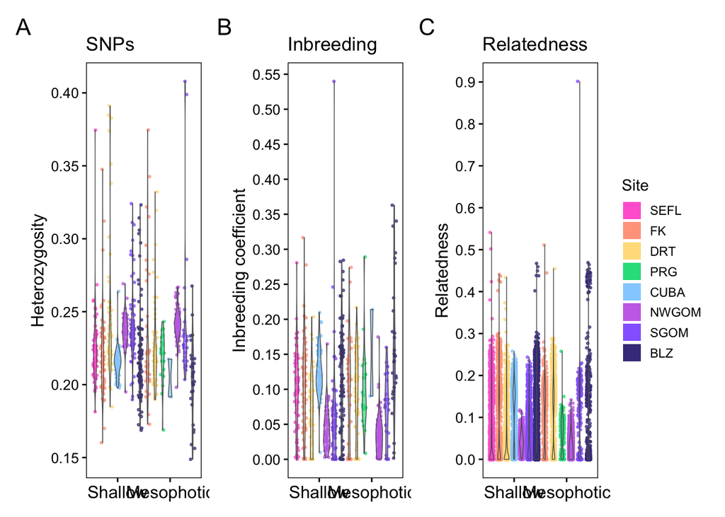

```r
colPal = c(paletteer_d("vapeplot::vaporwave")[c(7,10,11,14,1,5,3)], "slateblue4")
hetTheme = theme(axis.title.x = element_blank(),
                 axis.text.x = element_text(color = "black", size = 12),
                 axis.ticks.x = element_line(color = "black"),
                 axis.title.y = element_text(color = "black", size = 12),
                 axis.text.y = element_text(color = "black", size = 10),
                 axis.ticks.y = element_line(color = "black"),
                 legend.position = "right",
                 legend.key.size = unit(0.3, 'cm'),
                 panel.border = element_rect(color = "black"),
                 panel.background = element_rect(fill = "white"),
                 plot.background = element_rect(fill = "white"),
                 panel.grid.major = element_blank(),
                 panel.grid.minor = element_blank())
dodge <- position_dodge(width = 1)

hetPlotSnps = ggplot(data = popStats, aes(x = depthZone, y = hetSnps, fill = region)) +
  geom_point(aes(color = region),shape = 21, position = position_jitterdodge(seed = 1, dodge.width = 1), size = 0.5, alpha = 0.7) +
  geom_violin(size = 0.25, alpha = 0.7, position = dodge, color = "gray35") +
  xlab("Depth") +
  ylab("Heterozygosity") +
  ggtitle("SNPs") +
  scale_fill_manual(values = colPal,name = "Site") +
  scale_color_manual(values = colPal, name="Site") +
  scale_y_continuous(breaks=seq(0, 1, by = .05)) +
  theme_bw() +
  guides(fill = guide_legend(override.aes = list(shape = 22, size = 5, color = NA, alpha = NA)))+
  hetTheme

inbreedingPlot = ggplot(data = popStats, aes(x = depthZone, y = inbreed, fill = region)) +
  geom_point(aes(color = region),shape = 21, position = position_jitterdodge(seed = 1, dodge.width = 1), size = 0.5, alpha = 0.7) +
  geom_violin(size = 0.25, alpha = 0.7, position = dodge, color = "gray35") +
  xlab("Depth") +
  ylab("Inbreeding coefficient") +
  ggtitle("Inbreeding") +
  scale_fill_manual(values = colPal, name = "Site") +
  scale_color_manual(values = colPal, name = "Site") +
  scale_y_continuous(breaks=seq(0, 1, by = .05)) +
  guides(fill = guide_legend(override.aes = list(shape = 22, size = 5, color = NA, alpha = NA)))+
  theme_bw() +
  hetTheme

relatePlot = ggplot(data = mcavRelate, aes(x = depthZone, y = relate, fill = region)) +
  geom_point(aes(color = region),shape = 21, position = position_jitterdodge(seed = 1, dodge.width = 1), size = 0.5, alpha = 0.7) +
  geom_violin(size = 0.25, alpha = 0.7, position = dodge, color = "gray35") +
  xlab("Depth") +
  ylab("Relatedness") +
  ggtitle("Relatedness") +
  scale_fill_manual(values = colPal, name = "Site") +
  scale_color_manual(values = colPal, name="Site") +
  scale_y_continuous(breaks=seq(0, 1, by = .1)) +
  guides(fill = guide_legend(override.aes = list(shape = 22, size = 5, color = NA, alpha = NA)))+
  theme_bw() +
  hetTheme

hetPlots = ( hetPlotSnps | inbreedingPlot | relatePlot) +
  plot_annotation(tag_levels = 'A') +
  plot_layout(guides = "collect")&
  theme(plot.tag = element_text(size = 16),
        legend.position = "right")
hetPlots
```

```r
ggsave("../figures/fig2.tiff", plot = hetPlots, height = 5, width = 15, units = "in", dpi = 300)
```

##Analysis of Molecular Variance (AMOVA)

```r
regionalVcf = read.vcfR("../data/regionalMcavNoClones.bcf")
```

[output not shown]

```r
regionalGenlightPopDepth = vcfR2genlight(regionalVcf, n.cores = 2) # Converts the vcf file into a file format that poppr uses the "genlight" format
#locNames(regionalGenlightPopDepth) = paste(regionalVcf@fix[,1],regionalVcf@fix[,2],sep="_")
popData = read.csv("../data/regionalInds2PopsNoClones.csv") # Reads in population data for each sample

strata(regionalGenlightPopDepth) = data.frame(popData)
setPop(regionalGenlightPopDepth) = ~regionDepth
ploidy(regionalGenlightPopDepth) <- 2
amova <- poppr.amova(regionalGenlightPopDepth, ~regionDepth) #Runs AMOVA
amova
```

```
## $call
## ade4::amova(samples = xtab, distances = xdist, structures = xstruct)
##
## $results
##                                      Df   Sum Sq   Mean Sq
## Between regionDepth                  13  24110.2 1854.6309
## Between samples Within regionDepth  738 431915.0  585.2506
## Within samples                      752 398436.0  529.8351
## Total                              1503 854461.2  568.5038
##
## $componentsofcovariance
##                                                    Sigma          %
## Variations  Between regionDepth                 12.04648   2.114941
## Variations  Between samples Within regionDepth  27.70775   4.864514
## Variations  Within samples                     529.83511  93.020545
## Total variations                               569.58934 100.000000
##
## $statphi
##                                Phi
## Phi-samples-total       0.06979455
## Phi-samples-regionDepth 0.04969619
## Phi-regionDepth-total   0.02114941
```

```r
#Takes forever! Run with caution
set.seed(1999)
#amovasignif <- randtest(amova, nrepet = 99) #Calculates significance levels of the AMOVA with 99 permutations
#amovasignif
#plot(amovasignif)
#Test       Obs    Std.Obs   Alter Pvalue
# Variations between regionDepth  12.04648  76.358764 greater   0.01
```

There was significant genetic variation among our populations, let’s examine pairwise Fsts! ##Figure 3: Pairwise Fst heat map

```r
set.seed(694)
regional.fst <- stamppFst(regionalGenlightPopDepth, nboots = 99, percent = 95, nclusters = 4) #99 permutations
regional.fst$Fsts
```

```
##                  BLZShallow BLZMesophotic CUBAMesophotic CUBAShallow DRTMesophotic
## BLZShallow               NA            NA             NA          NA            NA
## BLZMesophotic   0.014938550            NA             NA          NA            NA
## CUBAMesophotic  0.065550547   0.034328259             NA          NA            NA
## CUBAShallow     0.028795834   0.061698179     0.12997853          NA            NA
## DRTMesophotic   0.015262308   0.009667373     0.01611718  0.06172629            NA
## DRTShallow      0.005986850   0.029972922     0.06859950  0.02695000  0.0231281996
## FKShallow       0.005862607   0.008981135     0.03082663  0.04669688  0.0031740563
## FKMesophotic    0.021795570   0.010385240     0.01454743  0.07130042  0.0004272394
## SGOMShallow     0.012766498   0.047094485     0.11377786  0.02622728  0.0397319368
## SGOMMesophotic  0.012724179   0.016938618     0.02914056  0.05259354  0.0052682939
## NWGOMMesophotic 0.013083700   0.031126897     0.06123469  0.03590436  0.0228063022
## NWGOMShallow    0.017666816   0.041986397     0.07583828  0.03318442  0.0339708931
## SEFLShallow     0.003808903   0.020303852     0.05323852  0.01926691  0.0175563082
## PRGMesophotic   0.015916561   0.046661881     0.09745352  0.02355885  0.0435681601
##                  DRTShallow   FKShallow FKMesophotic SGOMShallow SGOMMesophotic
## BLZShallow               NA          NA           NA          NA             NA
## BLZMesophotic            NA          NA           NA          NA             NA
## CUBAMesophotic           NA          NA           NA          NA             NA
## CUBAShallow              NA          NA           NA          NA             NA
## DRTMesophotic            NA          NA           NA          NA             NA
## DRTShallow               NA          NA           NA          NA             NA
## FKShallow       0.009005596          NA           NA          NA             NA
## FKMesophotic    0.033179971 0.009166069           NA          NA             NA
## SGOMShallow     0.009531825 0.024840585  0.048588057          NA             NA
## SGOMMesophotic  0.015396110 0.005528988  0.006660923 0.024753990             NA
## NWGOMMesophotic 0.015572136 0.018225096  0.024893990 0.011095893     0.01286011
## NWGOMShallow    0.015407474 0.025141396  0.038931151 0.009158006     0.02089536
## SEFLShallow     0.006440414 0.010044148  0.022513089 0.013637178     0.01206884
## PRGMesophotic   0.009164674 0.028112238  0.052416950 0.006163825     0.02972544
##                 NWGOMMesophotic NWGOMShallow SEFLShallow PRGMesophotic
## BLZShallow                   NA           NA          NA            NA
## BLZMesophotic                NA           NA          NA            NA
## CUBAMesophotic               NA           NA          NA            NA
## CUBAShallow                  NA           NA          NA            NA
## DRTMesophotic                NA           NA          NA            NA
## DRTShallow                   NA           NA          NA            NA
## FKShallow                    NA           NA          NA            NA
## FKMesophotic                 NA           NA          NA            NA
## SGOMShallow                  NA           NA          NA            NA
## SGOMMesophotic               NA           NA          NA            NA
## NWGOMMesophotic              NA           NA          NA            NA
## NWGOMShallow        0.002136613           NA          NA            NA
## SEFLShallow         0.011154973  0.014408297          NA            NA
## PRGMesophotic       0.012564922  0.006837382  0.01185407            NA
```

```r
regional.fst$Pvalues
```

```
##                 BLZShallow BLZMesophotic CUBAMesophotic CUBAShallow DRTMesophotic
## BLZShallow              NA            NA             NA          NA            NA
## BLZMesophotic            0            NA             NA          NA            NA
## CUBAMesophotic           0             0             NA          NA            NA
## CUBAShallow              0             0              0          NA            NA
## DRTMesophotic            0             0              0           0            NA
## DRTShallow               0             0              0           0    0.00000000
## FKShallow                0             0              0           0    0.00000000
## FKMesophotic             0             0              0           0    0.05050505
## SGOMShallow              0             0              0           0    0.00000000
## SGOMMesophotic           0             0              0           0    0.00000000
## NWGOMMesophotic          0             0              0           0    0.00000000
## NWGOMShallow             0             0              0           0    0.00000000
## SEFLShallow              0             0              0           0    0.00000000
## PRGMesophotic            0             0              0           0    0.00000000
##                 DRTShallow FKShallow FKMesophotic SGOMShallow SGOMMesophotic
## BLZShallow              NA        NA           NA          NA             NA
## BLZMesophotic           NA        NA           NA          NA             NA
## CUBAMesophotic          NA        NA           NA          NA             NA
## CUBAShallow             NA        NA           NA          NA             NA
## DRTMesophotic           NA        NA           NA          NA             NA
## DRTShallow              NA        NA           NA          NA             NA
## FKShallow                0        NA           NA          NA             NA
## FKMesophotic             0         0           NA          NA             NA
## SGOMShallow              0         0            0          NA             NA
## SGOMMesophotic           0         0            0           0             NA
## NWGOMMesophotic          0         0            0           0              0
## NWGOMShallow             0         0            0           0              0
## SEFLShallow              0         0            0           0              0
## PRGMesophotic            0         0            0           0              0
##                 NWGOMMesophotic NWGOMShallow SEFLShallow PRGMesophotic
## BLZShallow                   NA           NA          NA            NA
## BLZMesophotic                NA           NA          NA            NA
## CUBAMesophotic               NA           NA          NA            NA
## CUBAShallow                  NA           NA          NA            NA
## DRTMesophotic                NA           NA          NA            NA
## DRTShallow                   NA           NA          NA            NA
## FKShallow                    NA           NA          NA            NA
## FKMesophotic                 NA           NA          NA            NA
## SGOMShallow                  NA           NA          NA            NA
## SGOMMesophotic               NA           NA          NA            NA
## NWGOMMesophotic              NA           NA          NA            NA
## NWGOMShallow                  0           NA          NA            NA
## SEFLShallow                   0            0          NA            NA
## PRGMesophotic                 0            0           0            NA
```

```r
pop.order <- c("SEFLShallow", "FKShallow", "FKMesophotic", "DRTShallow", "DRTMesophotic", "PRGMesophotic", "CUBAShallow", "CUBAMesophotic", "NWGOMShallow", "NWGOMMesophotic", "SGOMShallow", "SGOMMesophotic", "BLZShallow", "BLZMesophotic")
# reads in fst matrix
snpFstMa <- as.matrix(regional.fst$Fsts)
upperTriangle(snpFstMa, byrow=TRUE) <- lowerTriangle(snpFstMa)
snpFstMa <- snpFstMa[,pop.order] %>%
  .[pop.order,]
snpFstMa[upper.tri(snpFstMa)] <- NA
snpFstMa <- as.data.frame(snpFstMa)

snpFstMa$Pop = factor(row.names(snpFstMa), levels = unique(pop.order))

snpQMa <- as.matrix(regional.fst$Pvalues)
upperTriangle(snpQMa, byrow=TRUE) <- lowerTriangle(snpQMa)
snpQMa <- snpQMa[,pop.order] %>%
  .[pop.order,]
snpQMa[upper.tri(snpQMa)] <- NA
snpQMa <- as.data.frame(snpQMa)
snpQMa$Pop = factor(row.names(snpQMa), levels = unique(pop.order))

snpFstMa$Pop = factor(row.names(snpFstMa), levels = unique(pop.order))
snpFst = melt(snpFstMa, id.vars = "Pop", value.name = "Fst", variable.name = "Pop2", na.rm = TRUE)
snpFst = snpFst[snpFst$Pop != snpFst$Pop2,]
snpFst$Fst = round(snpFst$Fst, 3)
snpFst = snpFst %>% mutate(Fst = replace(Fst, Fst < 0, 0))
head(snpFst)
```

```
##             Pop        Pop2   Fst
## 2     FKShallow SEFLShallow 0.010
## 3  FKMesophotic SEFLShallow 0.023
## 4    DRTShallow SEFLShallow 0.006
## 5 DRTMesophotic SEFLShallow 0.018
## 6 PRGMesophotic SEFLShallow 0.012
## 7   CUBAShallow SEFLShallow 0.019
```

```r
snpQ = melt(snpQMa, id.vars = "Pop", value.name = "Pval", variable.name = "Pop2", na.rm = TRUE)
snpQ = snpQ[snpQ$Pop != snpQ$Pop2,]
snpQ$Qval = p.adjust(snpQ$Pval, method = "BH")
head(snpQ)
```

```
##             Pop        Pop2 Pval Qval
## 2     FKShallow SEFLShallow    0    0
## 3  FKMesophotic SEFLShallow    0    0
## 4    DRTShallow SEFLShallow    0    0
## 5 DRTMesophotic SEFLShallow    0    0
## 6 PRGMesophotic SEFLShallow    0    0
## 7   CUBAShallow SEFLShallow    0    0
```

[figure not shown]

```r
snpHeatmapA = ggplot(data = snpFst, aes(Pop, Pop2, fill = Fst))+
  geom_tile(color = "white")+
  scale_fill_gradient2(low = "white", high = "turquoise", midpoint = 0, limit = c(0, 0.155),
                       space = "Lab", name = expression(paste(italic("F")[ST])))+
  geom_text(data = snpFst, aes(Pop, Pop2, label = Fst), color = ifelse(snpQ$Qval <= 0.05,"black", "darkgrey"), size = ifelse(snpQ$Qval < 0.05, 6, 5), fontface = ifelse(snpQ$Qval <= 0.05, "bold", "plain")) +
  guides(fill=guide_colorbar(barwidth = 1, barheight = 12, title.position = "top", title.hjust = 0.5))+
  scale_y_discrete(position = "right", labels=str_wrap(c("SEFL Shallow", "FK Shallow", "FK Mesophotic", "DRT Shallow", "DRT Mesophotic", "PRG Mesophotic", "CUBA Shallow", "CUBA Mesophotic", "NWGOM Shallow", "NWGOM Mesophotic", "SGOM Shallow", "SGOM Mesophotic", "BLZ Shallow")))+
  scale_x_discrete(labels = (c("FK\nShallow", "FK\nMesophotic", "DRT\nShallow", "DRT\nMesophotic", "PRG\nMesophotic", "CUBA\nShallow", "CUBA\nMesophotic", "NWGOM\nShallow", "NWGOM\nMesophotic", "SGOM\nShallow", "SGOM\nMesophotic", "BLZ\nShallow", "BLZ\nMesophotic"))) +
  #ggtitle("   SNP") +
  geom_rect(xmin=1.5, xmax=2.5, ymin=1.5, ymax=2.5, color="#FFA58BFF", fill=NA, size=2.5)+
  geom_rect(xmin=3.5, xmax=4.5, ymin=3.5, ymax=4.5, color="#FFDE8BFF" , fill=NA, size=2.5)+
  geom_rect(xmin=6.5, xmax=7.5, ymin=6.5, ymax=7.5, color="#94D0FFFF" , fill=NA,size=2.5)+
  geom_rect(xmin=8.5, xmax=9.5, ymin=8.5, ymax=9.5, color="#C774E8FF" , fill=NA,size=2.5)+
  geom_rect(xmin=10.5, xmax=11.5, ymin=10.5, ymax=11.5, color="#966BFFFF" , fill=NA,size=2.5)+
  geom_rect(xmin=12.5, xmax=13.5, ymin=12.5, ymax=13.5, color="slateblue4" , fill=NA,size=2.5)+
  #geom_rect(xmin=3.5, xmax=4.5, ymin=2.5, ymax=3.5, color="red" , fill=NA, size=2)+
  theme_minimal()

snpHeatmap = snpHeatmapA + theme(
  axis.text.x = element_text(vjust = 1, size = 16, hjust = 0.5, color = "black", angle=90),
  axis.text.y = element_text(size = 16, color = "black"),
  axis.title.x = element_blank(),
  axis.title.y = element_blank(),
  panel.grid.major = element_blank(),
  panel.border = element_blank(),
  panel.background = element_blank(),
  axis.ticks = element_blank(),
  legend.position = "right",
  legend.direction = "vertical",
  legend.title = element_text(size = 16, color="black"),
  legend.text = element_text(size = 14, color="black"),
  plot.title = element_text(size = 16)
)

snpHeatmap
```

```r
  ggsave("../figures/fig3.tiff", plot = snpHeatmap, width = 34, height = 15, units = "cm", dpi = 300)
```